# Week 7 Data Blitz Example. Alcohol

Psych 250a

Friday November 13

This document works through the [Week 7 Data Blitz](https://craigenders.github.io/psych250a/data-blitz/Week%207%20Data%20Blitz.%20Independent-Samples%20t-Test.html) using `Alcohol.csv`, comparing adults with a high school education or less and adults with some college or more (`College`) on smoking days per month (`CigDays`) and drinking days per month (`AlcDays`). It is one way to complete the activity, not the only acceptable one; written answers are examples of what a complete response covers.

# 1. Research Question

Do adults with a high school education or less and adults with some college or more differ with respect to the number of days per month they smoke (`CigDays`) and the number of days per month they drink (`AlcDays`)?

For smoking, the prediction is that adults with less education smoke on more days, because smoking rates are consistently higher in groups with less education. For drinking, the direction is less clear: education is associated with higher income and more social drinking, which could produce more drinking days among college-educated adults, but heavy drinking is not consistently more common in either group.

A two-tailed test is defensible even with a directional hypothesis. A result in the unexpected direction would be scientifically important and should be detectable, and a one-tailed test cannot detect it. The two-tailed test is also the convention in psychology, so readers will not suspect that the test was chosen after seeing the data to make a borderline result significant.

# 2. Packages, Data Import, and Factor Conversion

```r
# load R packages
library(ggplot2)
library(summarytools)
library(psych)

# store the web address of the raw data file
filepath <- "https://raw.githubusercontent.com/craigenders/psych250a/main/data/Alcohol.csv"

# read the file at that address into a data frame named Alcohol
Alcohol <- read.csv(filepath, stringsAsFactors = TRUE)

# convert College from 0/1 codes to a factor with descriptive labels
Alcohol$College <- factor(Alcohol$College, levels = c(0, 1), labels = c("High school or less", "Some college or more"))

# frequency distribution to confirm the labels are attached correctly
freq(Alcohol$College)
```

```
Frequencies
Alcohol$College
Type: Factor

                             Freq   % Valid   % Valid Cum.   % Total   % Total Cum.
-------------------------- ------ --------- -------------- --------- --------------
       High school or less   1078     71.87          71.87     71.87          71.87
      Some college or more    422     28.13         100.00     28.13         100.00
                      <NA>      0                               0.00         100.00
                     Total   1500    100.00         100.00    100.00         100.00
```

# 3. Descriptive Statistics by Group

```r
# descriptive statistics for every variable separately for each group (psych package)
describeBy(Alcohol, group = Alcohol$College)
```

```
 Descriptive statistics by group
group: High school or less
          vars    n   mean     sd median trimmed    mad min  max range skew kurtosis    se
ID           1 1078 735.15 431.54  718.5  732.49 558.20   1 1500  1499 0.05    -1.20 13.14
Male         2 1078   0.45   0.50    0.0    0.43   0.00   0    1     1 0.21    -1.96  0.02
Age          3 1078  26.98  16.42   20.0   23.92   8.90  12   85    73 1.53     1.65  0.50
College      4 1078   1.00   0.00    1.0    1.00   0.00   1    1     0  NaN      NaN  0.00
AgeTryCig    5 1078  16.72   2.87   16.0   16.44   1.48  10   48    38 3.48    26.30  0.09
CigDays      6 1078   5.90  10.37    0.0    3.65   0.00   0   30    30 1.63     1.05  0.32
AgeTryAlc    7 1078  16.27   3.47   16.0   15.98   1.48  10   44    34 1.88     8.54  0.11
AlcDays      8 1078   1.89   4.83    0.0    0.62   0.00   0   30    30 3.74    15.19  0.15
Drinker      9 1078   0.31   0.46    0.0    0.26   0.00   0    1     1 0.82    -1.33  0.01
DrinkFreq   10 1078   0.39   0.63    0.0    0.26   0.00   0    2     2 1.37     0.70  0.02
---------------------------------------------------------------------------
group: Some college or more
          vars   n   mean     sd median trimmed    mad min  max range  skew kurtosis    se
ID           1 422 789.71 435.32  855.0  797.00 535.22   2 1497  1495 -0.14    -1.18 21.19
Male         2 422   0.41   0.49    0.0    0.38   0.00   0    1     1  0.37    -1.86  0.02
Age          3 422  34.22  14.21   30.0   32.04  11.86  18   85    67  1.31     1.32  0.69
College      4 422   2.00   0.00    2.0    2.00   0.00   2    2     0   NaN      NaN  0.00
AgeTryCig    5 422  17.71   2.18   17.0   17.52   1.48  10   31    21  1.47     7.07  0.11
CigDays      6 422   5.56  10.50    0.0    3.21   0.00   0   30    30  1.71     1.20  0.51
AgeTryAlc    7 422  17.12   3.59   17.0   16.89   1.48  10   47    37  2.55    16.08  0.17
AlcDays      8 422   3.46   6.44    0.5    1.83   0.74   0   30    30  2.67     7.04  0.31
Drinker      9 422   0.50   0.50    0.5    0.50   0.74   0    1     1  0.00    -2.00  0.02
DrinkFreq   10 422   0.64   0.72    0.5    0.56   0.74   0    2     2  0.65    -0.85  0.04
```

# 4. Evaluation of the Mean Difference

## CigDays

Adults with a high school education or less smoke on an average of 5.90 days per month and adults with some college or more on 5.56 days, a difference of 0.34 days. Relative to a range of 0 to 30 days and standard deviations of about 10.4 days in each group, a difference of a third of a day is negligible. The difference is more consistent with the null hypothesis of no mean difference than with the prediction that less-educated adults smoke more often.

## AlcDays

Adults with some college or more drink on an average of 3.46 days per month and adults with a high school education or less on 1.89 days, a difference of 1.58 days. Relative to the 0 to 30 range the difference is modest, but it is large relative to the low means: the college group drinks on nearly twice as many days. The difference seems more consistent with a real group difference than with the null hypothesis, although the large standard deviations (4.83 and 6.44) call for a formal test.

# 5. Standard Error

```r
# Welch's t-test for CigDays, stored in an object
results_CigDays <- t.test(CigDays ~ College, data = Alcohol)

# standard error of the mean difference for CigDays
results_CigDays$stderr
```

```
[1] 0.60093
```

```r
# Welch's t-test for AlcDays, stored in an object
results_AlcDays <- t.test(AlcDays ~ College, data = Alcohol)

# standard error of the mean difference for AlcDays
results_AlcDays$stderr
```

```
[1] 0.3463485
```

## CigDays

The standard error of the mean difference is 0.60 days. It is the typical distance between a sample mean difference and the population mean difference across many hypothetical samples of these sizes. The observed difference of 0.34 days is only about half a standard error from zero, so a difference this size is exactly what sampling error alone would routinely produce. This strengthens the Task 4 conclusion that the data are consistent with the null hypothesis.

## AlcDays

The standard error of the mean difference is 0.35 days, the typical distance between a sample mean difference and the population mean difference across many hypothetical samples of these sizes. The observed difference of 1.58 days is about 4.5 standard errors from zero, far larger than sampling error would typically produce. This refines the Task 4 conclusion: the difference is inconsistent with the null hypothesis.

# 6. Independent-Samples *t*-Test and Effect Size

The *t*-test results were stored in Task 5; printing the objects shows the full output. `cohen.d()` gives the standardized mean difference.

```r
# Welch's t-test results for CigDays
results_CigDays
```

```
    Welch Two Sample t-test

data:  CigDays by College
t = 0.57069, df = 760.77, p-value = 0.5684
alternative hypothesis: true difference in means between group High school or less and group Some college or more is not equal to 0
95 percent confidence interval:
 -0.8367355  1.5226203
sample estimates:
 mean in group High school or less mean in group Some college or more
                          5.899814                           5.556872
```

```r
# standardized mean difference effect size for CigDays (psych package)
cohen.d(CigDays ~ College, data = Alcohol)
```

```
Call: cohen.d(x = CigDays ~ College, data = Alcohol)
Cohen d statistic of difference between two means
        lower effect upper
CigDays -0.15  -0.03  0.08

Multivariate (Mahalanobis) distance between groups
[1] 0.033
r equivalent of difference between two means
CigDays
  -0.01
```

```r
# Welch's t-test results for AlcDays
results_AlcDays
```

```
    Welch Two Sample t-test

data:  AlcDays by College
t = -4.547, df = 614.84, p-value = 0.000006556
alternative hypothesis: true difference in means between group High school or less and group Some college or more is not equal to 0
95 percent confidence interval:
 -2.255014 -0.894675
sample estimates:
 mean in group High school or less mean in group Some college or more
                          1.889610                           3.464455
```

```r
# standardized mean difference effect size for AlcDays (psych package)
cohen.d(AlcDays ~ College, data = Alcohol)
```

```
Call: cohen.d(x = AlcDays ~ College, data = Alcohol)
Cohen d statistic of difference between two means
        lower effect upper
AlcDays  0.18    0.3  0.41

Multivariate (Mahalanobis) distance between groups
[1] 0.3
r equivalent of difference between two means
AlcDays
   0.13
```

For smoking days, the means differ by only 0.34 days, *t*(760.77) = 0.57, *p* = .57, and the effect size is about 0.03 in absolute value, essentially zero. For drinking days, adults with some college or more report 1.58 more drinking days per month, *t*(614.84) = −4.55, *p* < .001, with an effect size of about 0.30 in absolute value, a small effect. The sign of *t* reflects the order of subtraction (high school or less minus some college or more); check the sign of the effect size against the group means, because `cohen.d()` may subtract in the other order.

# 7. Interpretation of the *p*-Value

## CigDays

The *p*-value of .57 is a conditional probability. The condition is that the null hypothesis is true: in the population, adults with a high school education or less and adults with some college or more smoke on the same average number of days. Given that condition, .57 is the probability of drawing samples of these sizes whose mean difference is at least as far from zero as the observed 0.34 days, in either direction. A difference this large or larger would occur in 57% of such samples, so the data are entirely ordinary under the null hypothesis.

## AlcDays

The *p*-value is less than .001, so we use .001 as its value. It is a conditional probability. The condition is that the null hypothesis is true: in the population, the two education groups drink on the same average number of days. Given that condition, the probability of drawing samples of these sizes whose mean difference is at least 1.58 days from zero, in either direction, is less than .001, fewer than 1 in 1,000 such samples. Data like ours would be very unusual if the null hypothesis were true.

# 8. Interpretation of the Confidence Interval

## CigDays

The 95% confidence interval for the population mean difference (high school or less minus some college or more) runs from −0.84 to 1.52 days. Under the extreme-populations interpretation, the lower limit is the smallest population mean difference that could plausibly have produced the observed difference of 0.34 days: if the population difference were −0.84, the observed 0.34 would sit at the upper edge of the middle 95% of that population’s sampling distribution. The upper limit, 1.52, is the largest such population difference, with 0.34 at the lower edge of its sampling distribution. The observed sample difference and its standard error are fixed; what varies is the hypothetical population mean difference. Because zero lies inside the interval, a population with no difference could easily have produced these data, so the interval does not reject the null hypothesis. This agrees with *p* = .57.

## AlcDays

The 95% confidence interval for the population mean difference (high school or less minus some college or more) runs from −2.26 to −0.90 days. The lower limit is the most negative population mean difference that could plausibly have produced the observed −1.58: if the population difference were −2.26, the observed value would sit at the upper edge of the middle 95% of that population’s sampling distribution. The upper limit, −0.90, is the population difference closest to zero for which −1.58 sits at the lower edge of the middle 95%. The observed difference and its standard error are fixed; the hypothetical population differences vary. Zero lies outside the interval, so a population with no difference is not a plausible source of these data. The interval leads to the same conclusion as the *p*-value: reject the null hypothesis.

# 9. Welch’s and Student’s *t*-Tests

Example prompt:

> I am comparing two independent groups with an independent-samples t-test in R. R’s t.test() function uses Welch’s t-test by default rather than the classic Student’s t-test. Compare and contrast the two procedures: what each assumes about the population variances, how each computes the standard error and degrees of freedom, and the circumstances (for example, unequal variances combined with unequal group sizes) under which their results are similar or different. Then tell me which procedure the methodological literature recommends as a default for psychology research. Support your conclusions with citations to published methodological studies and include links or DOIs so I can verify each source. In my data, the two groups are adults with a high school education or less (n = 1,078) and adults with some college or more (n = 422), and the outcomes are smoking days and drinking days per month (0 to 30).

AI’s response is not reproduced here; groups’ responses will differ. Before relying on any source AI cites, open the link and confirm that the article exists and says what AI claims. The sources below are real and are the ones most often cited on this question.

Example one-paragraph summary for a lab document:

R uses Welch’s *t*-test by default. The classic Student’s test pools the two group variances into a single estimate, which is correct only if the population variances are equal. Welch’s test estimates each group’s variance separately and adjusts the degrees of freedom accordingly. When the variances are equal, the two tests give nearly identical results, so little is lost by using Welch’s test. When the variances differ and the group sizes are unequal, Student’s test can be badly wrong: its Type I error rate rises above .05 when the smaller group has the larger variance and falls below .05 when the larger group has the larger variance. Simulation studies show that Welch’s test controls the Type I error rate across these conditions (Delacre et al., 2017; Ruxton, 2006), and testing equal variances first and then choosing a test performs worse than using Welch’s test unconditionally (Zimmerman, 2004). In these data the groups are very unequal in size (1,078 vs. 422), and for drinking days the smaller college group has the larger standard deviation (6.44 vs. 4.83), exactly the situation in which Student’s test is too liberal. We therefore report Welch’s test.

Delacre, M., Lakens, D., & Leys, C. (2017). Why psychologists should by default use Welch’s *t*-test instead of Student’s *t*-test. *International Review of Social Psychology, 30*(1), 92–101. https://doi.org/10.5334/irsp.82

Ruxton, G. D. (2006). The unequal variance *t*-test is an underused alternative to Student’s *t*-test and the Mann–Whitney *U* test. *Behavioral Ecology, 17*(4), 688–690. https://doi.org/10.1093/beheco/ark016

Zimmerman, D. W. (2004). A note on preliminary tests of equality of variances. *British Journal of Mathematical and Statistical Psychology, 57*(1), 173–181. https://doi.org/10.1348/000711004849222

For comparison, the classic Student’s test can be requested with `var.equal = TRUE`. This is not part of the task, but it shows concretely how much the choice matters in these data.

```r
# classic Student's t-test for CigDays, assuming equal variances
t.test(CigDays ~ College, data = Alcohol, var.equal = TRUE)
```

```
    Two Sample t-test

data:  CigDays by College
t = 0.57372, df = 1498, p-value = 0.5662
alternative hypothesis: true difference in means between group High school or less and group Some college or more is not equal to 0
95 percent confidence interval:
 -0.8295743  1.5154592
sample estimates:
 mean in group High school or less mean in group Some college or more
                          5.899814                           5.556872
```

```r
# classic Student's t-test for AlcDays, assuming equal variances
t.test(AlcDays ~ College, data = Alcohol, var.equal = TRUE)
```

```
    Two Sample t-test

data:  AlcDays by College
t = -5.1447, df = 1498, p-value = 0.0000003034
alternative hypothesis: true difference in means between group High school or less and group Some college or more is not equal to 0
95 percent confidence interval:
 -2.1752980 -0.9743912
sample estimates:
 mean in group High school or less mean in group Some college or more
                          1.889610                           3.464455
```

For smoking days, the two tests agree closely because the standard deviations are nearly equal (10.37 and 10.50). For drinking days they do not: Student’s test gives *t*(1498) = −5.15 with a standard error of 0.31, whereas Welch’s test gives *t*(614.84) = −4.55 with a standard error of 0.35. Because the smaller group has the larger variance, Student’s pooled standard error is too small and its *t* is inflated. The conclusion does not change here, but in a sample with a weaker effect it could.

# 10. Within-Group Normality

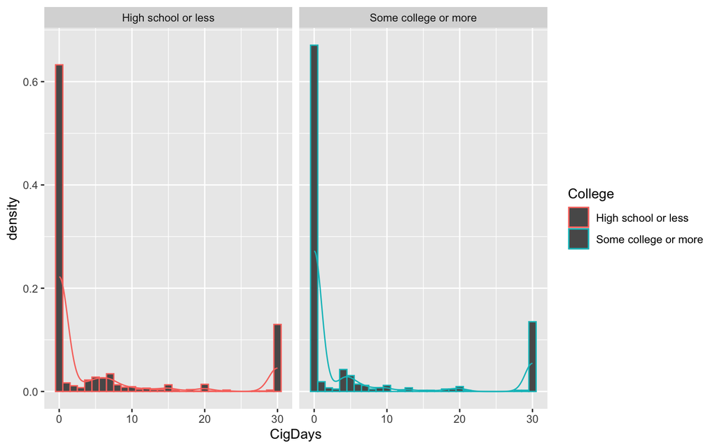

```r
# histogram with density curve for CigDays, one panel per College group
ggplot(Alcohol, aes(x = CigDays, colour = College)) +
  geom_histogram(aes(y = after_stat(density)), binwidth = 1) +
  geom_density() +
  facet_wrap(~ College)
```

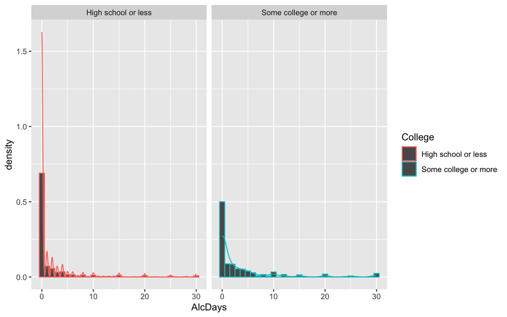

```r
# histogram with density curve for AlcDays, one panel per College group
ggplot(Alcohol, aes(x = AlcDays, colour = College)) +
  geom_histogram(aes(y = after_stat(density)), binwidth = 1) +
  geom_density() +
  facet_wrap(~ College)
```

## CigDays

Both distributions are strongly right-skewed: most adults smoke on zero days (the median in each group is 0), and a smaller cluster smokes every day, producing a spike at 30. Skewness is about 1.6 and 1.7 and kurtosis about 1.1 and 1.2. The normality assumption is not satisfied in either group. With 422 and 1,078 adults, however, the sampling distribution of the mean difference will be very close to normal, so the violation is unlikely to distort the *p*-value or confidence interval.

## AlcDays

Both distributions are severely right-skewed with long right tails. Most adults with a high school education or less report no drinking days (median 0), and the college group’s median is 0.5. Skewness is 3.74 (high school or less) and 2.67 (some college or more), and kurtosis is 15.19 and 7.04, reflecting a few adults who drink nearly every day. The normality assumption is clearly violated in both groups. Because the groups are large, the *t*-test’s *p*-value and interval for the mean difference remain approximately correct, but the means are pulled upward by the heavy right tail.

# 11. Answer to the Research Question

The data provide no evidence that education is related to smoking frequency. Adults with a high school education or less and adults with some college or more smoke on almost the same number of days per month (5.90 vs. 5.56), *t*(760.77) = 0.57, *p* = .57, *d* ≈ 0.03, and the 95% confidence interval for the population mean difference (−0.84 to 1.52 days) includes zero. This result does not support the prediction that less-educated adults smoke more often, although a nonsignificant test does not show that the population means are equal.

Education is related to drinking frequency. Adults with some college or more drink on 1.58 more days per month (3.46 vs. 1.89), *t*(614.84) = −4.55, *p* < .001, *d* ≈ 0.30, with a 95% confidence interval of 0.90 to 2.26 more days for the college group. The effect is small but clearly different from zero.

Welch’s test does not assume equal variances, which matters for drinking days. The normality assumption is clearly violated for both outcomes: the distributions are strongly right-skewed with most adults reporting zero days. Because the groups are large (422 to 1,078), the sampling distribution of the mean difference is close to normal and the *p*-values and intervals are trustworthy. The bigger concern is substantive: with medians of 0 or 0.5 days, the mean describes a minority of frequent smokers and drinkers rather than a typical adult, so the results should be described as differences in average frequency, not in typical behavior.

# 12. Reflection on AI

Responses will vary. Useful points to raise in discussion: whether the Task 9 citations checked out when the links were opened, whether AI recommended Welch’s test unconditionally or tied the recommendation to unequal variances and unequal group sizes, and whether AI’s explanation of the standard error matched the lecture’s definition.